# Text Mining

Dor Goldenberg

13 June, 2021

# Preface

Text is one of the most significant resources for social scientists. Nontheless it is very hard to parse due to its characteristics - most of the text in the world is neither structured nor labeled. Hence, we have to figure new ways to structure it and new algorithms to extract meaning out of it. In this exercise we will cover some basic aspects of Text Mining. In `R` there is a task named `The Natural Language Processing`. You can find the list of packages included in the task [here](https://cran.r-project.org/web/views/NaturalLanguageProcessing.html). We will analyze some classic books: we will try to find what are the important words in each one of them, what is the sentiment throughout the book and we will try to find ways to figure the clusters of texts in a corpus.

### Libraries and Data

Load the libraries listed below.

```r
library(tidyverse)
library(gutenbergr)
library(magrittr)
library(tidytext)
library(scales)
library(igraph)
library(ggraph)
library(scales)
library(topicmodels)
set.seed(2017)
```

##### Exercises

For this exercise we will use the `gutenbergr` package.

**Project Gutenberg (PG)** is a volunteer effort to digitize and archive cultural works, to “encourage the creation and distribution of eBooks” (Wikipedia)

The `gutenbergr` package gives an API to the project - it allows the user to get the metadata of a writer or a book; it also allows to download the books in the project.

1. Use the `gutenberg_works(author == "Surname, First name")` function to download the metadata of Mark Twain and Lewis Carroll.
2. Use the `gutenberg_download(gutenberg_id)` to download the following books: Alice’s Adventures in Wonderland, Through the Looking-Glass, The Adventures of Tom Sawyer, Adventures of Huckleberry Finn, A Connecticut Yankee in King Arthur’s Court, The Innocents Abroad {this book includes the title “Pleasure Excursion to the Holy Land”}, The Count of Monte Cristo).

# Tokens & Stop Words

The concept of tokens is fundamental in text mining - it asks what are basic unit of interest - word, sentence, n-grams, paragraphs? Stop words are common words that we don’t want to include in our analysis such as “of”, “the”, “in”. In most cases thses words can only stand in our way. ##### Exercises 1. For each book use the `unnest_tokens` function to split it to words. Use the `data(stop_words)` function to load the stop words to your environment. Attach title to each gutenberg_id. You data should look like this:

```
## # A tibble: 6 x 4
##   gutenberg_id word       author     title
##          <int> <chr>      <chr>      <chr>
## 1           74 adventures Mark Twain The Adventures of Tom Sawyer
## 2           74 tom        Mark Twain The Adventures of Tom Sawyer
## 3           74 sawyer     Mark Twain The Adventures of Tom Sawyer
## 4           74 mark       Mark Twain The Adventures of Tom Sawyer
## 5           74 twain      Mark Twain The Adventures of Tom Sawyer
## 6           74 samuel     Mark Twain The Adventures of Tom Sawyer
```

2. What are the 15 most common words in Twain’s books? Use the `count` function.
3. Plot the common words. You should get something like the following plot:

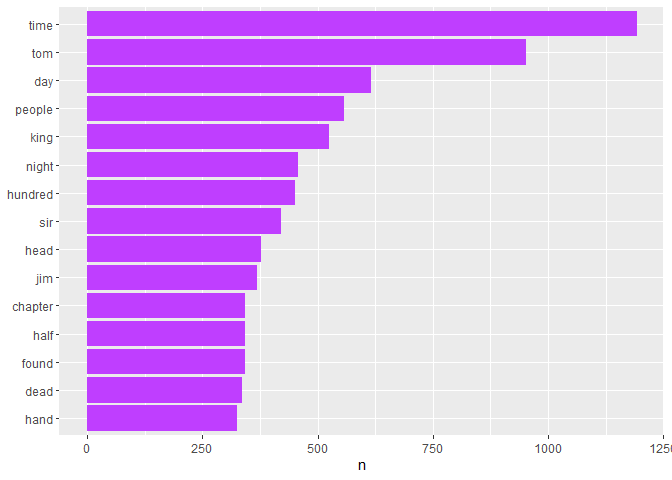

4. Adapt the following code so it will fit your code:

```r
frequency <- bind_rows(your_tidy_carroll,
                       your_tidy_duma,
                       your_tidy_twain) %>%
  mutate(word = str_extract(word, "[a-z']+")) %>%
  count(author, word) %>%
  group_by(author) %>%
  mutate(proportion = n / sum(n)) %>%
  select(-n) %>%
  spread(author, proportion) %>%
  gather(author, proportion, `Alexander Duma`:`Lewis Carroll`)
```

Make sure that you spelled the author names correctly in your code. Make sure that your code has the following columns names:

```
## [1] "gutenberg_id" "word"         "author"       "title"
```

5. Adapt the following code so it will fit your code:

```r
ggplot(your_data_from_above, aes(x = proportion, y = `Mark Twain`, color = abs(`Mark Twain` - proportion))) +
  geom_abline(color = "gray40", lty = 2) +
  geom_jitter(alpha = 0.1, size = 2.5, width = 0.3, height = 0.3) +
  geom_text(aes(label = word), check_overlap = TRUE, vjust = 1.5) +
  scale_x_log10(labels = percent_format()) +
  scale_y_log10(labels = percent_format()) +
  scale_color_gradient(limits = c(0, 0.001), low = "darkslategray4", high = "gray75") +
  facet_wrap(~author, ncol = 2) +
  theme(legend.position="none") +
  labs(y = "Mark Twain", x = NULL)
```

You should get the following plot. Can you interpret it?

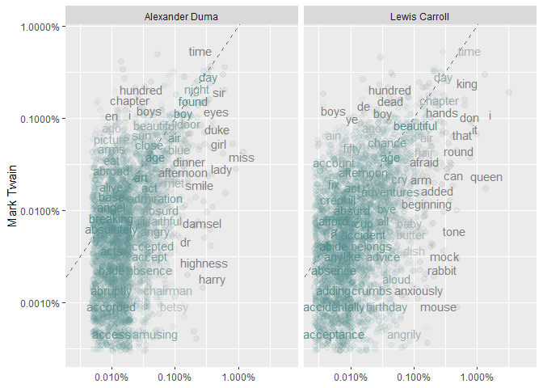

6. Whose writing is more similar to Twain’s lingo? Use the `cor.test` function to find put. (You may use the following code).

```r
cor.test(data = frequency %>% filter(author == "Author Name"),
         ~ proportion + `Mark Twain`)
```

# Sentiment Analysis

In many cases we would like to know what is the sentiment in a text even without understanding the text. The most basic (and problematic) way of doing it is to use sentiment lexicons. Sentiment lexicons are pre-defined lexicons in which words get tags - it can be either a score or some label. We will use 3 lexicons: “afinn”, “bing” and “nrc”. There are some lexicon concerning specific fields (like the “Loughran” lexicon).

##### Exercises

1. Use the `get_sentiments(lexicon)` function to get the data. Use it with the above lexicons.

```
## # A tibble: 2,477 x 2
##    word       value
##    <chr>      <dbl>
##  1 abandon       -2
##  2 abandoned     -2
##  3 abandons      -2
##  4 abducted      -2
##  5 abduction     -2
##  6 abductions    -2
##  7 abhor         -3
##  8 abhorred      -3
##  9 abhorrent     -3
## 10 abhors        -3
## # ... with 2,467 more rows
```

```
## # A tibble: 6,786 x 2
##    word        sentiment
##    <chr>       <chr>
##  1 2-faces     negative
##  2 abnormal    negative
##  3 abolish     negative
##  4 abominable  negative
##  5 abominably  negative
##  6 abominate   negative
##  7 abomination negative
##  8 abort       negative
##  9 aborted     negative
## 10 aborts      negative
## # ... with 6,776 more rows
```

```
## # A tibble: 13,901 x 2
##    word        sentiment
##    <chr>       <chr>
##  1 abacus      trust
##  2 abandon     fear
##  3 abandon     negative
##  4 abandon     sadness
##  5 abandoned   anger
##  6 abandoned   fear
##  7 abandoned   negative
##  8 abandoned   sadness
##  9 abandonment anger
## 10 abandonment fear
## # ... with 13,891 more rows
```

2. Adapt the following code so it will fit your code:

```r
twain_chapters <- twain_books %>%
  group_by(gutenberg_id) %>%
  mutate(linenumber = row_number(),
         chapter = cumsum(as.numeric(str_detect(text, regex("^chapter [\\divxlc]",
                                                 ignore_case = TRUE))))) %>%
  ungroup() %>%
  unnest_tokens(word, text)

 twain_chapters %<>%
   left_join(select(twain_metadata, gutenberg_id, title), by = "gutenberg_id")
```

3. Extract the joy-related words from the `nrc` lexicon. Use this words to find what are the 10- most common joyful words in the book “A Connecticut Yankee in King Arthur’s Court” (You can see the first 3). Can you think of a problem with this method given these joyful words?

```
## # A tibble: 3 x 2
##   word       n
##   <chr>  <int>
## 1 good     246
## 2 church    57
## 3 found     57
```

4. Adapt the following code so it will fit your code:

```r
mark_twain_sentiment <- twain_chapters %>%
  inner_join(get_sentiments("bing"), by = "word") %>%
  count(title, index = linenumber %/% 80, sentiment) %>%
  spread(sentiment, n, fill = 0) %>%
  mutate(sentiment = positive - negative)
```

5. Plot the data from the former chunck - the index on the x-axis, and the sentiment on the y-axis. Use different color for each book. Use `geom_col`. Use facets for books (use the `facet_wrap` argument). You should get something like this plot:

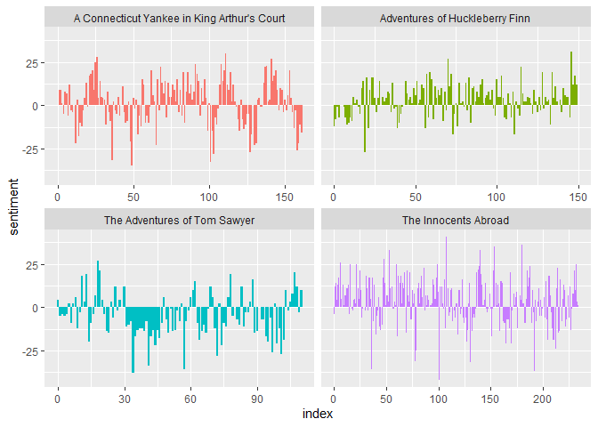

We can see that “A Connecticut Yankee in King Arthur’s Court” ends up not so well. It fits the plot of the book (if you haven’t read it yet read it - it’s a good book).

## The problems of sentiment analysis

There many caveats to be aware of when you use lexicons. First and foremost - sentiment is really contextual: “good” is a positive word, right? What about “not good”? We can deal with these common negations like “not” or “never” but language is much more complicated than this. Another problem is the range of sentiments. We can express textualy much more sentiments than “positive” or “negative”, and even more than the 10 sentiments in the “nrc” lexicon. We will see some example of the second problem now. We will see how the sentiment of huckleberry_finn changes with different lexicons.

##### Exercise

1. Assign huckleberry_finn to its own variable. It should look like this:

```
## # A tibble: 10 x 5
##    gutenberg_id linenumber chapter word        title
##           <int>      <int>   <dbl> <chr>       <chr>
##  1           76          1       0 adventures  Adventures of Huckleberry Finn
##  2           76          3       0 of          Adventures of Huckleberry Finn
##  3           76          5       0 huckleberry Adventures of Huckleberry Finn
##  4           76          5       0 finn        Adventures of Huckleberry Finn
##  5           76          7       0 tom         Adventures of Huckleberry Finn
##  6           76          7       0 sawyer's    Adventures of Huckleberry Finn
##  7           76          7       0 comrade     Adventures of Huckleberry Finn
##  8           76          9       0 by          Adventures of Huckleberry Finn
##  9           76          9       0 mark        Adventures of Huckleberry Finn
## 10           76          9       0 twain       Adventures of Huckleberry Finn
```

2. Adapt the following code so it will fit your code:

```r
afinn <- huckleberry_finn %>%
  inner_join(get_sentiments("afinn"), by = "word") %>%
  group_by(index = linenumber %/% 80) %>%
  summarise(sentiment = sum(value)) %>%
  mutate(method = "AFINN")

bing_and_nrc <- bind_rows(huckleberry_finn %>%
                            inner_join(get_sentiments("bing"), by = "word") %>%
                            mutate(method = "Bing et al."),
                          huckleberry_finn %>%
                            inner_join(get_sentiments("nrc") %>%
                                         filter(sentiment %in% c("positive",
                                                                 "negative")), by = "word") %>%
                            mutate(method = "NRC")) %>%
  count(method, index = linenumber %/% 80, sentiment) %>%
  spread(sentiment, n, fill = 0) %>%
  mutate(sentiment = positive - negative)

huck_finn_sentiment <- bind_rows(afinn,bing_and_nrc)
```

In this chunck we do what we did above, except this time we used three lexicons.

3. Plot the data from the former chunck: the index on the x-axis, and the sentiment on the y-axis. Use different color for each book. Use `geom_col`. Use facets for methods (use the `facet_wrap` argument). You should get something like this plot:

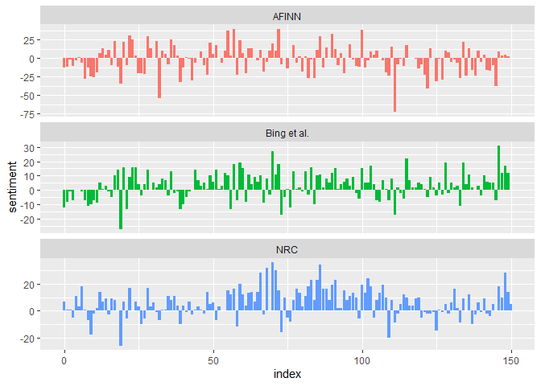

You can see that the lexicons don’t always agree on the sentiment of the section.

# n-grams

Not always our unit of interest is a word. Sometimes a meaningful unit composes of few words. The problem is that sometimes a phrase can be composes of seperately meaningful words. There is no straight forward way to distinguish between words that are part of n-grams and words that stand for themselves.

##### Exercises

1. Use the `unnest_tokens` function to split Mark Twain’s books to 2-grams. Print the 10 first results. (You can see the first three).

```
## # A tibble: 3 x 2
##   gutenberg_id bigram
##          <int> <chr>
## 1           74 the adventures
## 2           74 adventures of
## 3           74 of tom
```

2. What is the 10 most common 2-grams? (You can see the first three).

```
## # A tibble: 3 x 2
##   bigram     n
##   <chr>  <int>
## 1 NA      9960
## 2 of the  3003
## 3 in the  2355
```

You can see that the 2-grams aren’t very revealing.

3. Filter the stop words and print the 10 most common 2-grams again. (You can see the first three).

```
## # A tibble: 3 x 3
##   word1 word2      n
##   <chr> <chr>  <int>
## 1 NA    NA      9960
## 2 tom   sawyer    65
## 3 aunt  polly     56
```

4. Filter the data you filtered above - keep only 2-grams with more than 10 occurrences. Use the function `graph_from_data_frame` to create a graph object. Print the graph you created. It should look like this:

```
## IGRAPH 300530e DN-- 110 72 --
## + attr: name (v/c), n (e/n)
## + edges from 300530e (vertex names):
##  [1] NA       ->NA        tom      ->sawyer    aunt     ->polly
##  [4] sir      ->launcelot injun    ->joe       mary     ->jane
##  [7] aunt     ->sally     holy     ->land      hundred  ->yards
## [10] hundred  ->feet      sir      ->marhaus   sunday   ->school
## [13] centuries->ago       st       ->peter's   sir      ->kay
## [16] sir      ->sagramor  ten      ->minutes   holy     ->sepulchre
## [19] miss     ->watson    muff     ->potter    thousand ->dollars
## [22] dead     ->sea       mars     ->tom       miss     ->mary
## + ... omitted several edges
```

It is an `igraph` object. We will not go into the details of how to read it but the basic idea is describing the connections within a group. In our case the group is a text and the connections are adjacency of words. So for example “tom” and “sawyer” are connected to each other.

5. Adapt the following code so it will fit your code:

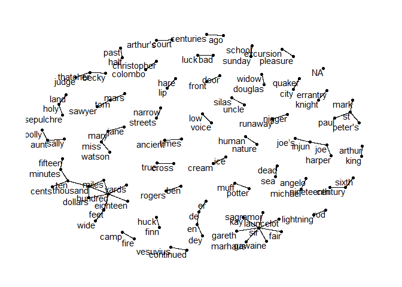

```r
ggraph(your_bigram_graph, layout = "fr") +
  geom_edge_link() +
  geom_node_point() +
  geom_node_text(aes(label = name), vjust = 1, hjust = 1)+
  theme_graph()
```

# Topic Modeling - Latent Dirchlet Allocation (LDA)

Sometimes we want to cluster our data to natural clusters. As we described in the unsupervised exercise the problem with clustering is that we don’t have an external validation to the ultimate clusters. LDA doesn’t deal with this problem but it has a method to get internal validity in a specific situation. The main assumptions of LDA are that each document is composes of mixture of pre-defined subjects and every subject composes of mixture of words. The subjects can overlap - words can be drawn from several subjects lingo. Each of the aforementioned distributions are highll skewed - and that’s where the “Dirchlet” comes from. So what LDA does is taking a corpus of documents (it can be a tweet, for example) ant by doing some kind of ML (Maximum Liklihood in that case) it tries to find what is most likely k clusters where k is a pre-defined parameter of the model. This model gives internal validity of clusters rather than external validity since it does not use any kind of feedback (like rmse or accuracy). It gives internal validity in the sense that we can use some metrics of cohesiveness or [perplexity](https://en.wikipedia.org/wiki/Perplexity).

##### Exercises

In this exercise we will take some of our books and divide them into chapters. We will try to assess which chapter belongs to which book, in other words we will try to make clusters of chapters that correspond to the ground truth - the books.

1. Adapt the following code so it will fit your code:

```r
books <- bind_rows(twain_books, carroll_books)
book_ids <- data.frame(
  title = c("Alice's Adventures in Wonderland", "Through the Looking-Glass  ", "The Adventures of Tom Sawyer", "Adventures of Huckleberry Finn", "A Connecticut Yankee in King Arthur's Court", "The Innocents Abroad"), gutenberg_id = c(11,12,74,76,86,3176))
books %<>% left_join(book_ids, by = "gutenberg_id")

by_chapter <- books %>%
  group_by(title) %>%
  mutate(chapter = cumsum(as.numeric(str_detect(text, regex("^chapter ", ignore_case = TRUE))))) %>%
  ungroup() %>%
  filter(chapter > 0) %>%
  unite(document, title, chapter)

# split into words
by_chapter_word <- by_chapter %>%
  unnest_tokens(word, text)

# find document-word counts
word_counts <- by_chapter_word %>%
  anti_join(stop_words, by = "word") %>%
  count(document, word, sort = TRUE) %>%
  ungroup()

word_counts %>% head(10)

#dtm is the format we need for LDA
chapters_dtm <- word_counts %>%
  cast_dtm(document, word, n)

chapters_dtm
```

```
## # A tibble: 10 x 3
##    document                                        word       n
##    <chr>                                           <chr>  <int>
##  1 "Adventures of Huckleberry Finn_51"             de        96
##  2 "Through the Looking-Glass\t_9"                 queen     89
##  3 "Adventures of Huckleberry Finn_51"             en        72
##  4 "Through the Looking-Glass\t_9"                 alice     72
##  5 "The Adventures of Tom Sawyer_66"               tom       58
##  6 "Through the Looking-Glass\t_6"                 alice     57
##  7 "A Connecticut Yankee in King Arthur's Court_9" sir       56
##  8 "Through the Looking-Glass\t_8"                 knight    55
##  9 "Through the Looking-Glass\t_5"                 alice     54
## 10 "The Adventures of Tom Sawyer_41"               tom       53
```

```
## <<DocumentTermMatrix (documents: 286, terms: 22628)>>
## Non-/sparse entries: 126405/6345203
## Sparsity           : 98%
## Maximal term length: 70
## Weighting          : term frequency (tf)
```

2. Use the LDA function to fit LDA model to the `chapters_dtm` object. How many topics do you need? (use the `k` argument to define the number of topics). Use the `control = list(seed = 1234)` argument for reproducibility.
3. Use the `tidy` function from `broom` with the argument `matrix = "beta"` to show the per-word probability estimated by the model. Assign your result to a variable.
4. Use `dplyr` syntax to show the 5 most probable words per topic. (You can see sample of 8 words)

```
## # A tibble: 8 x 3
##   topic term       beta
##   <int> <chr>     <dbl>
## 1     6 de      0.00760
## 2     6 en      0.00707
## 3     2 time    0.00774
## 4     4 it’s    0.00544
## 5     4 huck    0.00808
## 6     1 people  0.00430
## 7     2 don’t   0.00722
## 8     1 hundred 0.00364
```

5. Plot the results in the following way: words on the x-axis, beta on the y-axis, Use `geom_col`, `facet_wrap(~ topic)` and `coord_flip()`. It should look something like this:

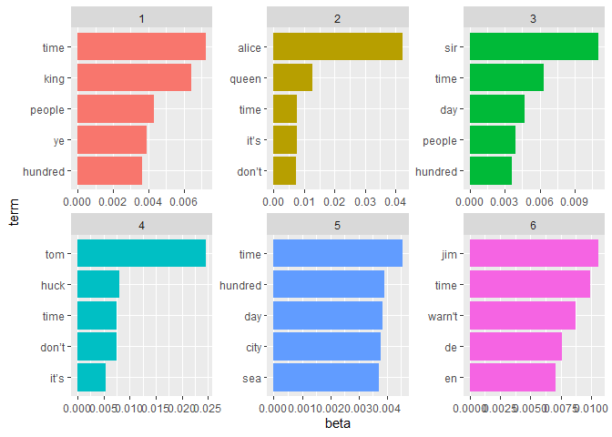

6. Use the `tidy` function from `broom` with the argument `matrix = "gamma"` to show the per-topic probability estimated by the model. Assign your result to a variable.

```
## # A tibble: 10 x 3
##    document                                         topic     gamma
##    <chr>                                            <int>     <dbl>
##  1 "Adventures of Huckleberry Finn_51"                  1 0.0000118
##  2 "Through the Looking-Glass\t_9"                      1 0.0000138
##  3 "The Adventures of Tom Sawyer_66"                    1 0.0000185
##  4 "Through the Looking-Glass\t_6"                      1 0.0000193
##  5 "A Connecticut Yankee in King Arthur's Court_9"      1 0.0000256
##  6 "Through the Looking-Glass\t_8"                      1 0.0000155
##  7 "Through the Looking-Glass\t_5"                      1 0.0000203
##  8 "The Adventures of Tom Sawyer_41"                    1 0.0000143
##  9 "A Connecticut Yankee in King Arthur's Court_43"     1 0.0000145
## 10 "Alice's Adventures in Wonderland_7"                 1 0.0000265
```

7. Adapt the following code so it will fit yours. It will seperate the chapter number to a different column.

```r
chapters_gamma <- chapters_gamma %>%
  separate(document, c("title", "chapter"), sep = "_", convert = TRUE)

chapters_gamma %>% head(10)
```

```
## # A tibble: 10 x 4
##    title                                         chapter topic     gamma
##    <chr>                                           <int> <int>     <dbl>
##  1 "Adventures of Huckleberry Finn"                   51     1 0.0000118
##  2 "Through the Looking-Glass\t"                       9     1 0.0000138
##  3 "The Adventures of Tom Sawyer"                     66     1 0.0000185
##  4 "Through the Looking-Glass\t"                       6     1 0.0000193
##  5 "A Connecticut Yankee in King Arthur's Court"       9     1 0.0000256
##  6 "Through the Looking-Glass\t"                       8     1 0.0000155
##  7 "Through the Looking-Glass\t"                       5     1 0.0000203
##  8 "The Adventures of Tom Sawyer"                     41     1 0.0000143
##  9 "A Connecticut Yankee in King Arthur's Court"      43     1 0.0000145
## 10 "Alice's Adventures in Wonderland"                  7     1 0.0000265
```

8. Per each title and chapter find the higest gamma. Use the `top_n(1, gamma)` function in your code (Hint: you need to use `group_by`). You can see some randomly chosen output below.

```
## # A tibble: 10 x 4
##    title                                       chapter topic gamma
##    <chr>                                         <int> <int> <dbl>
##  1 The Adventures of Tom Sawyer                     56     5 0.772
##  2 The Adventures of Tom Sawyer                     35     4 1.00
##  3 The Innocents Abroad                             41     5 1.00
##  4 A Connecticut Yankee in King Arthur's Court      26     1 1.00
##  5 The Adventures of Tom Sawyer                     41     4 1.00
##  6 The Innocents Abroad                             26     1 1.00
##  7 The Innocents Abroad                              1     5 1.00
##  8 The Adventures of Tom Sawyer                     10     4 0.988
##  9 Adventures of Huckleberry Finn                   21     6 0.992
## 10 Alice's Adventures in Wonderland                  3     2 1.00
```

The more homogeneous the results are the better the classifier is. If it would have been one-to-one results than it would have been a perfect classifier.

9. Adapt the following code so it will fit your code:

```r
book_topics <- chapter_classifications %>%
  count(title, topic) %>%
  group_by(title) %>%
  top_n(1, n) %>%
  ungroup() %>%
  transmute(consensus = title, topic)

chapter_classifications %>%
  inner_join(book_topics, by = "topic") %>%
  filter(title != consensus)
```

```
## # A tibble: 55 x 5
##    title                  chapter topic gamma consensus
##    <chr>                    <int> <int> <dbl> <chr>
##  1 The Innocents Abroad        53     1 1.00  A Connecticut Yankee in King Arth~
##  2 The Innocents Abroad        26     1 1.00  A Connecticut Yankee in King Arth~
##  3 The Innocents Abroad        31     1 1.00  A Connecticut Yankee in King Arth~
##  4 The Innocents Abroad        18     1 1.00  A Connecticut Yankee in King Arth~
##  5 The Innocents Abroad        55     1 0.519 A Connecticut Yankee in King Arth~
##  6 The Innocents Abroad        54     1 0.936 A Connecticut Yankee in King Arth~
##  7 The Innocents Abroad        58     1 0.599 A Connecticut Yankee in King Arth~
##  8 The Innocents Abroad        47     1 0.526 A Connecticut Yankee in King Arth~
##  9 The Innocents Abroad        21     1 1.00  A Connecticut Yankee in King Arth~
## 10 The Adventures of Tom~      40     1 0.684 A Connecticut Yankee in King Arth~
## # ... with 45 more rows
```

10. Use the `augment` function to show for each word in each document to which topic it was assigned. Print 20 random results (use `sample_n` for this goal).

```
## # A tibble: 20 x 4
##    document                                         term      count .topic
##    <chr>                                            <chr>     <dbl>  <dbl>
##  1 "The Innocents Abroad_38"                        fatted        1      5
##  2 "A Connecticut Yankee in King Arthur's Court_39" denounced     1      1
##  3 "A Connecticut Yankee in King Arthur's Court_28" mind          1      1
##  4 "The Adventures of Tom Sawyer_69"                bother        1      4
##  5 "The Innocents Abroad_8"                         soulless      1      5
##  6 "The Innocents Abroad_31"                        nineteen      1      1
##  7 "The Innocents Abroad_34"                        revels        1      4
##  8 "The Innocents Abroad_38"                        deck          1      5
##  9 "The Innocents Abroad_37"                        wool          1      3
## 10 "A Connecticut Yankee in King Arthur's Court_38" cavern        1      1
## 11 "The Adventures of Tom Sawyer_41"                couldn’t      1      4
## 12 "Adventures of Huckleberry Finn_64"              knife         1      6
## 13 "A Connecticut Yankee in King Arthur's Court_23" war           1      1
## 14 "The Innocents Abroad_6"                         patched       1      5
## 15 "The Adventures of Tom Sawyer_50"                explore       1      4
## 16 "The Innocents Abroad_44"                        hour's        1      5
## 17 "Through the Looking-Glass\t_5"                  hour          1      2
## 18 "The Innocents Abroad_61"                        broad         1      5
## 19 "The Innocents Abroad_37"                        army          1      3
## 20 "Adventures of Huckleberry Finn_62"              noticed       1      6
```

11. Adapt the following code so it will fit your code:

```r
assignments <- your_data_from_10 %>%
  separate(document, c("title", "chapter"), sep = "_", convert = TRUE) %>%
  inner_join(book_topics, by = c(".topic" = "topic"))

assignments %>%
  sample_n(20)
```

```
## # A tibble: 20 x 6
##    title                   chapter term    count .topic consensus
##    <chr>                     <int> <chr>   <dbl>  <dbl> <chr>
##  1 "The Innocents Abroad"       19 smelled     1      5 "The Innocents Abroad"
##  2 "Through the Looking-G~       1 tree        1      2 "Alice's Adventures in ~
##  3 "A Connecticut Yankee ~       7 extinc~     1      5 "The Innocents Abroad"
##  4 "A Connecticut Yankee ~      14 mill        1      1 "A Connecticut Yankee i~
##  5 "The Innocents Abroad"       49 career      1      5 "The Innocents Abroad"
##  6 "The Adventures of Tom~      43 fell        3      4 "The Adventures of Tom ~
##  7 "The Adventures of Tom~      55 hesita~     1      4 "The Adventures of Tom ~
##  8 "A Connecticut Yankee ~      20 boss        1      1 "A Connecticut Yankee i~
##  9 "The Innocents Abroad"       50 leaves      1      5 "The Innocents Abroad"
## 10 "The Adventures of Tom~      11 xi          1      4 "The Adventures of Tom ~
## 11 "Adventures of Huckleb~      54 moment      1      6 "Adventures of Hucklebe~
## 12 "The Innocents Abroad"       19 cospet~     1      5 "The Innocents Abroad"
## 13 "Through the Looking-G~      11 xi          1      2 "Through the Looking-Gl~
## 14 "The Innocents Abroad"       18 size        3      1 "A Connecticut Yankee i~
## 15 "Through the Looking-G~       3 _it_        1      2 "Through the Looking-Gl~
## 16 "The Innocents Abroad"       43 combin~     1      5 "The Innocents Abroad"
## 17 "A Connecticut Yankee ~      21 path        1      4 "The Adventures of Tom ~
## 18 "The Innocents Abroad"        6 unclean     1      5 "The Innocents Abroad"
## 19 "Adventures of Huckleb~      82 village     1      6 "Adventures of Hucklebe~
## 20 "Adventures of Huckleb~      63 fairly      1      6 "Adventures of Hucklebe~
```

12. Run the following code:

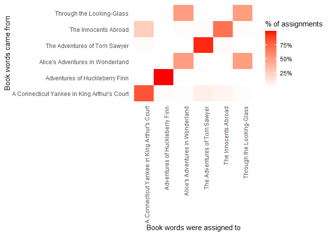

```r
assignments %>%
  count(title, consensus, wt = count) %>%
  group_by(title) %>%
  mutate(percent = n / sum(n)) %>%
  ggplot(aes(consensus, title, fill = percent)) +
  geom_tile() +
  scale_fill_gradient2(high = "red", label = percent_format()) +
  theme_minimal() +
  theme(axis.text.x = element_text(angle = 90, hjust = 1),
        panel.grid = element_blank()) +
  labs(x = "Book words were assigned to",
       y = "Book words came from",
       fill = "% of assignments")
```

13. Interpret the results.

Good Luck!!